# Multivariate Stats III

[figure not shown]

### Geometric Morphometrics (GM)

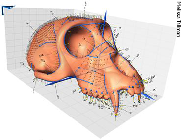

## involves the analysis of Cartesian geometric coordinates rather than length, area, volume measurements

### Steps in a GM analysis

## use `geomorph` package in R

1. Get coordinate data (e.g., digitize outline from a photo, use a microscribe, get 3D coordinates from laser scanned specimen, etc)
2. Perform a Generalized Procrustes Analysis (GPA)
3. Analyze and visualze the results from the GPA

### GM - Step 1 - Coordinates

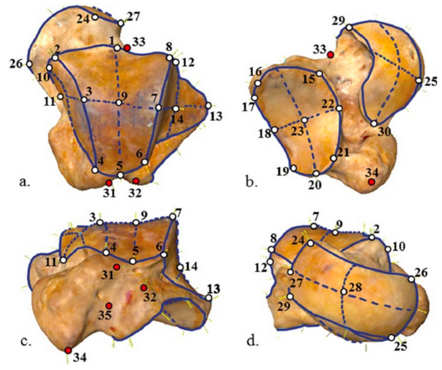

- involves capturing homologous *landmarks* or *semi-landmarks*
- can be 2D or 3D
- each specimen will have a unique *configuration* of landmarks in its own coordinate system

### GM - Step 1 - Coordinates

## We will use 2D coordinate data of salamander head shape

## note that the landmark is in a \( p \times k \times n \) array

```r
library(geomorph)
data(plethodon)
str(plethodon$land)
```

```
 num [1:12, 1:2, 1:40] 8.89 9.27 5.56 1.87 1.28 ...
 - attr(*, "dimnames")=List of 3
  ..$ : NULL
  ..$ : NULL
  ..$ : NULL
```

### GM - Step 2 - Procrustes

[figure not shown]

### GM - Step 2 - Procrustes

## Translates all configurations to the origin

## scales them to centroid size

## rotates them until the *Procrustes distance* between configurations is minimized

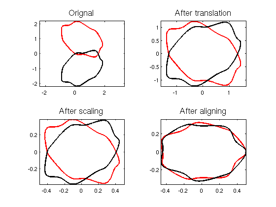

### GM - Step 2 - Procrustes

```r
GPA_pleth <- gpagen(plethodon$land)
```

```r
GPA_pleth
```

```
Call:
gpagen(A = plethodon$land)



Generalized Procrustes Analysis
with Partial Procrustes Superimposition

12 fixed landmarks
0 semilandmarks (sliders)
2-dimensional landmarks
2 GPA iterations to converge


Consensus (mean) Configuration

                X            Y
 [1,]  0.15233235 -0.025236626
 [2,]  0.19328978 -0.095041326
 [3,] -0.03370053 -0.006929886
 [4,] -0.28182427 -0.089370884
 [5,] -0.31072667 -0.057833073
 [6,] -0.32600020 -0.032082163
 [7,] -0.31757271  0.040056683
 [8,] -0.18824427  0.100347120
 [9,]  0.02159274  0.098853350
[10,]  0.18946790  0.074940129
[11,]  0.35213100  0.061515224
[12,]  0.54925486 -0.069218549
```

### GM - Step 3 - Analyze and Visualize

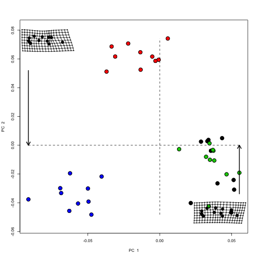

```r
gp <- as.factor(paste(plethodon$species, plethodon$site))
PCA <- plotTangentSpace(GPA_pleth$coords, groups = gp)
```

### GM - Step 3 - Analyze and Visualize

## you can do TONS of analyses using the functions in the `geomorph` package

## Questions?

### Non-Metric Multidimensional Scaling

## designed to create a diagram of relationships between objects

## based on the distance matrix

### Non-Metric Multidimensional Scaling

## Steps in the analysis

- generate a distance matrix (often euclidian) \( D \). Each element \( D_{ij} \) is the euclidian distance between the \( ith \) and \( jth \) observation.
- choose the number of dimensions \( n \) to use
- start by placing the \( m \) observations in an initial configuration in \( n \) dimensional space
- compute new distances: \( \delta_{ij} \) for the points in the initial configuration
- do a regression of \( \delta_{ij} \) on \( d_{ij} \), and use this regression to produce a set of expected distance values \( \hat{\delta}_{ij} \)

### Non-Metric Multidimensional Scaling

## Steps in the analysis

- compute a goodness of fit between \( \delta_{ij} \) and \( \hat{\delta}_{ij} \). This is the current **stress** of the configuration \[ Stress = \sqrt{\frac{\sum\limits_{i=1}^m\sum\limits_{j=1}^n(\delta_{ij}-\hat{\delta}_{ij})^2}{\sum\limits_{i=1}^m\sum\limits_{j=1}^n\hat{\delta}_{ij}}} \]
- note that stress looks an awful lot like the chi-square statistic
- change the position of the observations a little to reduce the stress, and rinse and repeat until the stress cannot be reduced any more

### The vegan package

## Widely used for community ecology

## has some useful ordination functions, distance metrics, and diversity indices

```r
#install.packages('vegan')
library("vegan")
vignette(package="vegan")
```

### vegan - distance

- more options for distance matrices including: bray, jaccard, gower, raup, mahalanobis, etc

```r
data(BCI)
vegdist(BCI, method="jaccard")
```

[output not shown]

[output cut: 295 more lines]

```
36
37
38
39
40
41
42
43
44 0.4486692
45 0.4721724 0.4602888
46 0.7240854 0.7131902 0.7442529
47 0.6449511 0.6260297 0.6671779 0.5078534
48 0.5704348 0.5492958 0.5918033 0.6458333 0.5159011
49 0.5160142 0.4936937 0.5161840 0.7452416 0.6497623 0.4856115
50 0.4462963 0.4901257 0.4844291 0.6939394 0.5927750 0.5061728 0.4550360
```

### vegan - diversity

- `diversity()` calculates common diversity metrics including: shannon-weaver, fischer, simpson, etc

```r
diversity(BCI, index = "shannon")
```

```
       1        2        3        4        5        6        7        8
4.018412 3.848471 3.814060 3.976563 3.969940 3.776575 3.836811 3.908381
       9       10       11       12       13       14       15       16
3.761331 3.889803 3.859814 3.698414 3.982373 4.017494 3.956635 3.916821
      17       18       19       20       21       22       23       24
3.736897 3.944985 4.013094 4.077327 3.969925 3.755413 4.062575 3.979427
      25       26       27       28       29       30       31       32
4.074718 3.947749 3.980281 3.693896 3.688721 3.851598 3.724967 3.784873
      33       34       35       36       37       38       39       40
3.740392 3.821669 2.641859 3.846109 3.791703 3.516082 3.530494 3.234849
      41       42       43       44       45       46       47       48
4.052495 3.966614 3.736254 3.705016 3.609518 3.810489 3.920918 3.913725
      49       50
3.778851 3.906616
```

### vegan - rarefaction

- species richness increases with sample size, so it is common practice to use *rarefaction* to resample larger assemblages to a smaller size

```r
rarefy(BCI, min(rowSums(BCI)))[1:5]
```

```
       1        2        3        4        5
84.33992 76.53165 79.11504 82.46571 86.90901
```

### vegan - rarefaction

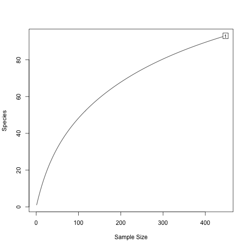

```r
rarecurve(BCI[1,], step = 4)
```

### vegan - ordination

- Detrended correspondence analysis

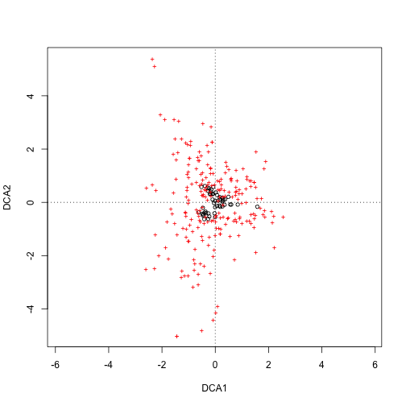

```r
plot(decorana(BCI))
```

### vegan - ordination

- Non-metric multidimensional scaling

```
Square root transformation
Wisconsin double standardization
... procrustes: rmse 0.01747669  max resid 0.09639988
... procrustes: rmse 0.00107791  max resid 0.004799762
*** Solution reached
```

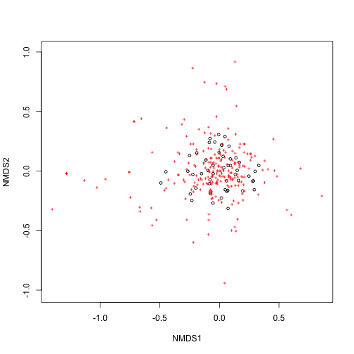

```r
result <- plot(metaMDS(BCI, k=3))
```

### vegan - ordination

- Non-metric multidimensional scaling

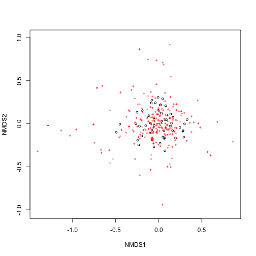

```r
ordiplot(result)
```